# Objectives:

The objective of this lab is to introduce the student to OpenCV/python, especially for image processing.

1. Reading an image in python
2. Convert Images to another format
3. Convert an Image to Grayscale
4. Perform Image enhancement operations

# Reading and displaying an image in python

[figure not shown]

```python
import matplotlib.pyplot as plt
import matplotlib.image as mpimg

image = mpimg.imread('H:/My Drive/U.S.A.R/6th Semester/Lab/sampleimg.tif')

plt.imshow(image, cmap='gray')
```

# Convert Images to another format and compare them

```python
from PIL import Image
import os

img = Image.open('H:/My Drive/U.S.A.R/6th Semester/Lab/f14.tif')
img.save('f14_img_1.tif')
img.save('f14_img_1.jpg')
img.save('f14_img_1.png')
img.save('f14_img_1.jpeg')
img.save('f14_img_1.gif')

print("size of file in tiff",round(os.path.getsize('f14_img_1.tif')/1024,2),"KB")
print("size of file in jpg",round(os.path.getsize('f14_img_1.jpg')/1024,2),"KB")
print("size of file in jpeg",round(os.path.getsize('f14_img_1.jpeg')/1024,2),"KB")
print("size of file in png",round(os.path.getsize('f14_img_1.png')/1024,2),"KB")
print("size of file in gif",round(os.path.getsize('f14_img_1.gif')/1024,2),"KB")
```

```
size of file in tiff 300.17 KB
size of file in jpg 22.1 KB
size of file in jpeg 22.1 KB
size of file in png 144.35 KB
size of file in gif 212.61 KB
```

# Convert an Image to Grayscale and display

```python
from PIL import Image
img = Image.open('H:/My Drive/U.S.A.R/6th Semester/Lab/football_seal.tif').convert('L')
img.save('footbal_seal_update.tif')
```

[figure not shown]

```python
plt.subplot(1,2,1)
plt.imshow(mpimg.imread('H:/My Drive/U.S.A.R/6th Semester/Lab/football_seal.tif'))
plt.title("colorful")
plt.subplot(1,2,2)
plt.imshow(img, cmap='gray')
plt.title("grey")
```

# Perform Image enhancement operations

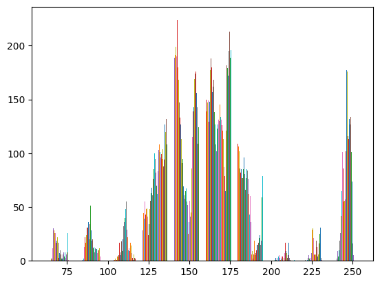

```python
plt.hist(image)
```

[figure not shown]

```python
plt.imshow(image, cmap='grey')
```

```python
import numpy as np
x_new=np.copy(image)
for i in range(image.shape[0]):
    for j in range(image.shape[1]):
        if image[50,j]<=image[i,j]<=image[i,150]:
            x_new[i,j]=150
        else:
            pass
```

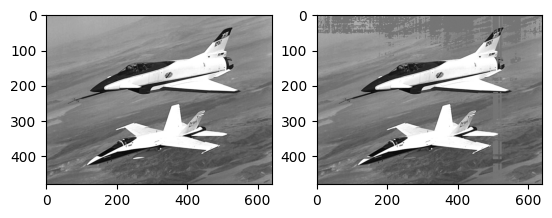

```python
plt.subplot(1,2,1)
plt.imshow(image,cmap='grey')

plt.subplot(1,2,2)
plt.imshow(x_new,cmap='grey')
```

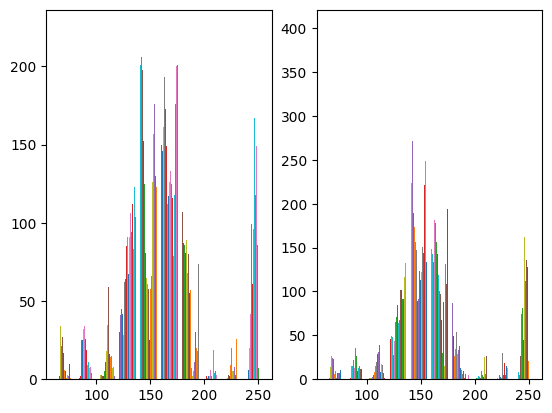

```python
plt.subplot(1,2,1)
plt.hist(image)
plt.subplot(1,2,2)
plt.hist(x_new)
```

# Perform Image enhancement operations

Image enhancement is a crucial step in image processing that aims to improve the visual appearance of an image or to convert the image to a form better suited for analysis by a human or machine. The need for image enhancement arises due to various factors such as poor lighting conditions, low contrast, noise, and other degradations that can affect the quality of an image.

Types of image enhancement methods include:

1. **Histogram Equalization**: This method improves the contrast of an image by effectively spreading out the most frequent intensity values. It is useful for images with backgrounds and foregrounds that are both bright or both dark.
2. **Contrast Stretching**: This technique enhances the contrast by stretching the range of intensity values so that it spans the full intensity range. It is useful for images with low contrast.
3. **Smoothing**: This method reduces noise and fine details in an image. It is often used in preprocessing steps to remove high-frequency noise.
4. **Sharpening**: This technique enhances the edges and fine details in an image. It is useful for highlighting important features.
5. **Filtering**: Various filters (e.g., Gaussian, median) can be applied to an image to achieve different enhancement effects, such as noise reduction or edge enhancement.

By applying these methods, the quality of images can be significantly improved, making them more suitable for further analysis and interpretation.

[figure not shown]

```python
import cv2
import matplotlib.pyplot as plt
import numpy as np

# Load the image using cv2.imread()
testimg = cv2.imread('H:/My Drive/U.S.A.R/6th Semester/Lab/sampleimg.tif')
plt.imshow(testimg)
```

```python
testimg.shape
```

```
(480, 640, 3)
```

```python
minval=256
maxval=-1
for i in range(480):
    for j in range(640):
        # Convert RGB to grayscale by taking the mean of the RGB values
        grayscale_value = int(np.mean(testimg[i][j]))
        maxval = max(maxval, grayscale_value)
        minval = min(minval, grayscale_value)
print(minval)
print(maxval)
```

```
61
255
```

```python
arr = [0]*256
```

```python
for i in range(testimg.shape[0]):
    for j in range(testimg.shape[1]):
        # Get the average intensity of the RGB channels for grayscale representation
        intensity = int(np.mean(testimg[i][j]))
        arr[intensity] += 1
```

```python
print(arr)
```

```
[0, 0, 0, 0, 0, 0, 0, 0, 0, 0, 0, 0, 0, 0, 0, 0, 0, 0, 0, 0, 0, 0, 0, 0, 0, 0, 0, 0, 0, 0, 0, 0, 0, 0, 0, 0, 0, 0, 0, 0, 0, 0, 0, 0, 0, 0, 0, 0, 0, 0, 0, 0, 0, 0, 0, 0, 0, 0, 0, 0, 0, 19, 45, 76, 91, 108, 125, 176, 405, 315, 348, 321, 327, 312, 394, 395, 384, 405, 355, 360, 337, 335, 354, 357, 430, …
```

```python
summ=0
for i in range(len(arr)):
    summ+=arr[i]
print(summ)
```

```
307200
```

```python
probarr=[arr[i]/summ for i in range(len(arr))]
```

```python
print(probarr)
```

[output not shown]

```python
summ=0
for i in range(len(probarr)):
    summ+=probarr[i]
print(summ)
```

```
1.0000000000000004
```

```python
print(len(probarr))
```

```
256
```

```python
cdf=[0]*256
for i in range(len(probarr)):
    j=0
    val=probarr[i]
    while j<i:
        val+=probarr[j]
        j+=1
    cdf[i]=val
print(cdf)
```

[output not shown]

```python
#Previous cells where you calculate 'probarr' should be executed before this cell.
#...

cdf=[0]*256
for i in range(len(probarr)):
    j=0
    val=probarr[i]
    while j<i:
        val+=probarr[j]
        j+=1
    cdf[i]=val
print(cdf)

#Now, cdf is defined and you can use it in the next line
print(len(cdf))
```

[output not shown]

```python
cdf=[cdf[i]*maxval for i in range(len(cdf))]
```

```python
print(cdf)
```

[output not shown]

```python
cdf = [round(cdf[i]) for i in range(len(cdf))]
```

```python
print(cdf)
```

```
[0, 0, 0, 0, 0, 0, 0, 0, 0, 0, 0, 0, 0, 0, 0, 0, 0, 0, 0, 0, 0, 0, 0, 0, 0, 0, 0, 0, 0, 0, 0, 0, 0, 0, 0, 0, 0, 0, 0, 0, 0, 0, 0, 0, 0, 0, 0, 0, 0, 0, 0, 0, 0, 0, 0, 0, 0, 0, 0, 0, 0, 0, 0, 0, 0, 0, 0, 1, 1, 1, 1, 2, 2, 2, 3, 3, 3, 4, 4, 4, 4, 5, 5, 5, 6, 6, 7, 7, 7, 8, 8, 8, 9, 9, 10, 10, 10, 10, 1…
```

```python
cdf=[round(cdf[i]) for i in range(len(cdf))]
```

```python
print(cdf)
```

```
[0, 0, 0, 0, 0, 0, 0, 0, 0, 0, 0, 0, 0, 0, 0, 0, 0, 0, 0, 0, 0, 0, 0, 0, 0, 0, 0, 0, 0, 0, 0, 0, 0, 0, 0, 0, 0, 0, 0, 0, 0, 0, 0, 0, 0, 0, 0, 0, 0, 0, 0, 0, 0, 0, 0, 0, 0, 0, 0, 0, 0, 0, 0, 0, 0, 0, 0, 1, 1, 1, 1, 2, 2, 2, 3, 3, 3, 4, 4, 4, 4, 5, 5, 5, 6, 6, 7, 7, 7, 8, 8, 8, 9, 9, 10, 10, 10, 10, 1…
```

```python
import numpy as np
```

```python
enhanced_img=np.array(testimg)
enhanced_img.shape
```

```
(480, 640, 3)
```

```python
for i in range(testimg.shape[0]):
    for j in range(testimg.shape[1]):
        grayscale_value = int(np.mean(testimg[i][j]))
        enhanced_img[i][j] = cdf[grayscale_value]
```

[figure not shown]

```python
plt.imshow(testimg,cmap='gray')
```

[figure not shown]

```python
plt.imshow(enhanced_img,cmap='gray')
```

# Conclusion

In this notebook, we explored various fundamental image processing operations using Python and popular libraries such as OpenCV, PIL, and Matplotlib. We started by reading and displaying images using `matplotlib.pyplot` and `matplotlib.image`. We then converted images to different formats and compared their file sizes to understand the impact of different formats on storage.

Next, we converted an image to grayscale and displayed both the original and grayscale images using subplots for comparison. We performed image enhancement operations, including histogram equalization, to improve the visual quality of the images. We calculated the cumulative distribution function (CDF) and applied it to enhance the image contrast.

Throughout this notebook, we learned how to manipulate and enhance images, understand the importance of different image formats, and apply various image processing techniques to improve image quality. These skills are essential for any computer vision task and provide a solid foundation for more advanced image processing and analysis.

By implementing these operations, we gained hands-on experience with image processing, which is crucial for practical applications in computer vision and related fields.